# Concurrent Programming - List 1

José Benardi de Souza Nunes, Gustavo Diniz Monteiro, Ruan Roberto Eloy Silveira

```r
library(here)
library(boot)
library(readr)
library(dplyr)
library(ggplot2)
library(lubridate)

theme_set(theme_bw())
```

# Question 1

## Implementation

In this problem let us compare two versions of a program that’s supposed to count to 3E7 by means of three threads:

- The `unprotected` version where no measure is taken to curb the behavior of threads
- The `protected` version where measures are taken to prevent one thread from messing with the work of the others

### Unprotected version

- Code can be found at `code/list1/c-code/ex1/unprotected_ex1.c`

```c
#include <stdio.h>
#include <assert.h>
#include <pthread.h>

long int counter = 0;

void* run(void* args) {
  int my_id;
  long int j;

  my_id = (int) args;

  for(j = 0; j < 1e7; j++) {
    counter = counter + 1;
  }

  printf("my_id=%d j=%ld counter=%ld\n", my_id, j, counter);
  pthread_exit(my_id);
}

int main(int argc, char *argv[]) {
  int i;
  pthread_t pthreads[3];

  for(i = 0; i < 3; i++) {
    pthread_create(&pthreads[i], NULL, &run, (void*) i);
  }

  for(i = 0; i < 3; i++) {
    pthread_join(pthreads[i], NULL);
  }

  printf("counter=%ld\n", counter);

  return(0);
}
```

### Protected version

- Code can be found at `code/list1/c-code/ex1/protected_ex1.c`

```c
#include <stdio.h>
#include <assert.h>
#include <pthread.h>

long int counter = 0;

void* run(void* args) {
  int my_id;
  long int j;

  my_id = (int) args;

  for(j = 0; j < 1e7; j++) {
    counter = counter + 1;
  }

  printf("my_id=%d j=%ld counter=%ld\n", my_id, j, counter);
  pthread_exit(my_id);
}

int main(int argc, char *argv[]) {
  int i;
  pthread_t pthreads[3];

  for(i = 0; i < 3; i++) {
    pthread_create(&pthreads[i], NULL, &run, (void*) i);
    pthread_join(pthreads[i], NULL);
  }
  printf("counter=%ld\n", counter);

  return(0);
}
```

## Performance comparison

##### To compare how each version fares performance wise let’s check the results of the following experiment:

Factors:

- `version`: where the program is ‘protected’ or ‘unprotected’

Metrics:

- `RSS` : Maximum resident set size of the process during its lifetime, in Kilobytes.
- `elapsed` : Elapsed real (wall clock) time used by the process, in [hours:]minutes:seconds.
- `cpu.sys` : Total number of CPU-seconds used by the system on behalf of the process (in kernel mode), in seconds.
- `.user` : Total number of CPU-seconds that the process used directly (in user mode), in seconds.
- `minor_pagefault` : Number of minor, or recoverable, page faults. These are pages that are not valid (so they fault) but which have not yet been claimed by other virtual pages. Thus the data in the page is still valid but the system tables must be updated.
- `major_pagefault` : Number of major, or I/O-requiring, page faults that occurred while the process was running. These are faults where the page has actually migrated out of primary memory.
- `inv_cxt_sw` : Number of times the process was context-switched involuntarily (because the time slice expired).
- `vol_cxt_sw` : Number of times that the program was context-switched voluntarily, for instance while waiting for an I/O operation to complete
- `execution` : Number of the execution

> For each combination of factor levels we had 50 repetitions, which gives us 100 executions.

### Load Data

```r
read_csv(here::here("output/list1/ex1/perf_result.csv"),
         progress = F,
         col_types = cols(
           RSS = col_integer(),
           elapsed = col_character(),
           cpu.sys = col_double(),
           .user = col_double(),
           minor_pagefault = col_integer(),
           major_pagefault = col_integer(),
           inv_cxt_sw = col_integer(),
           vol_cxt_sw = col_integer(),
           version = col_character(),
           execution = col_integer())) %>%
  mutate(elapsed = lubridate::ms(elapsed),
         version = as.factor(version)) %>%
  mutate(elapsed = lubridate::second(elapsed)) -> perf_data

perf_data %>%
  glimpse()
```

```
## Observations: 100
## Variables: 10
## $ RSS             <int> 1568, 1516, 1660, 1608, 1532, 1640, 1588, 1632...
## $ elapsed         <dbl> 0.14, 0.09, 0.14, 0.08, 0.15, 0.08, 0.14, 0.07...
## $ cpu.sys         <dbl> 0, 0, 0, 0, 0, 0, 0, 0, 0, 0, 0, 0, 0, 0, 0, 0...
## $ .user           <dbl> 0.33, 0.08, 0.36, 0.08, 0.39, 0.08, 0.32, 0.07...
## $ minor_pagefault <int> 0, 0, 0, 0, 0, 0, 0, 0, 0, 0, 0, 0, 0, 0, 0, 0...
## $ major_pagefault <int> 84, 82, 85, 81, 86, 81, 87, 83, 86, 82, 87, 84...
## $ inv_cxt_sw      <int> 210, 17, 89, 5, 120, 13, 140, 1, 148, 8, 186, ...
## $ vol_cxt_sw      <int> 3, 4, 2, 4, 2, 4, 3, 4, 3, 4, 2, 4, 3, 4, 4, 4...
## $ version         <fct> unprotected, protected, unprotected, protected...
## $ execution       <int> 1, 1, 2, 2, 3, 3, 4, 4, 5, 5, 6, 6, 7, 7, 8, 8...
```

### Elapsed Time

#### Descriptive Analysis

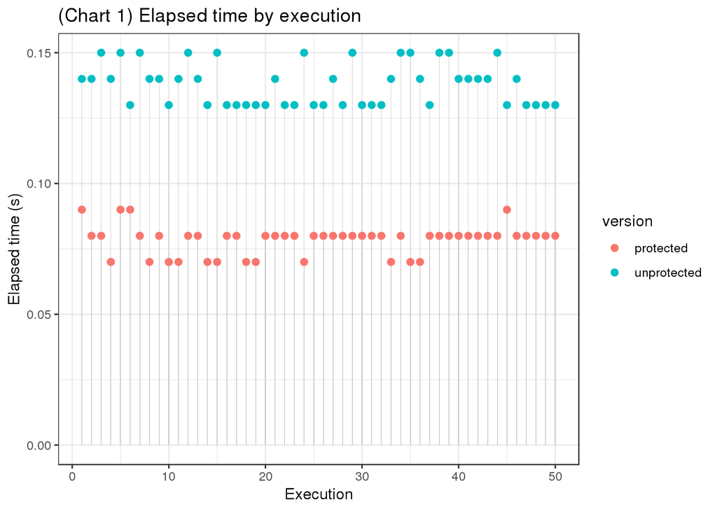

```r
perf_data %>%
  ggplot(aes(execution,elapsed,color=version)) +
    geom_segment(aes(x = execution, y = 0,
                     xend = execution, yend = elapsed),
                 color = "grey50", size=0.06) +
  geom_point(size=2) +
  labs(x="Execution", y= "Elapsed time (s)",
       title="(Chart 1) Elapsed time by execution")
```

- We can notice a substantially longer elapsed time in the executions of the `unprotected` version compared to the `protected` one.

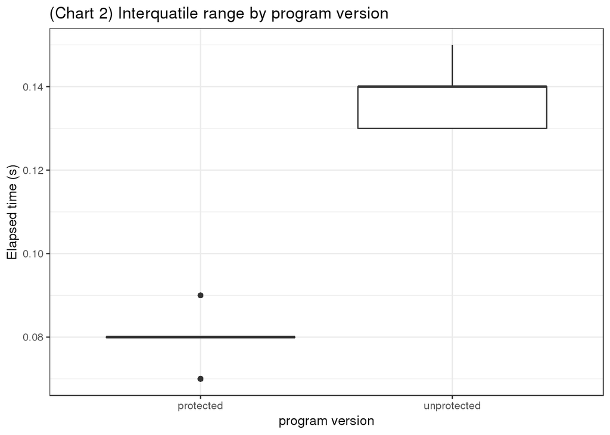

```r
perf_data %>%
  ggplot(aes(version,elapsed)) +
  geom_boxplot() +
  labs(y="Elapsed time (s)",x="program version",
       title="(Chart 2) Interquatile range by program version")
```

- Results similar to those of *Chart 1*.

#### Statistical Inference

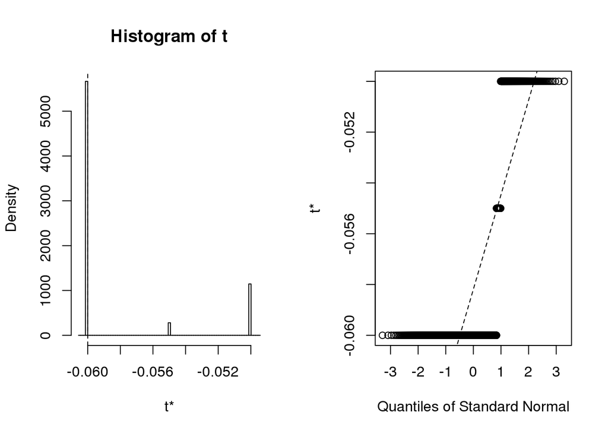

```r
my_theta <- function(x, i) {
    x %>%
        slice(i) -> d

    d %>%
      group_by(version) %>%
      summarise(med = median(elapsed, na.rm = TRUE)) -> y

    med_diff = y[y$version == "protected",]$med - y[y$version == "unprotected",]$med

    return(med_diff)
}

med_diff.boot <- boot(data = perf_data,
                 statistic = my_theta,
                 R = 2000)

plot(med_diff.boot)
```

- We have a weird-tailed distributions that quite deviates from the normal, looking at the density plot it’s most likely due to a lack of variance, for this reason let’s use the `basic CI` (also called pivotal or empirical CI) to extract our results.

```r
result_med_diff <- boot.ci(boot.out = med_diff.boot,
        conf = 0.95,
        type = "basic")

result_med_diff
```

```
## BOOTSTRAP CONFIDENCE INTERVAL CALCULATIONS
## Based on 2000 bootstrap replicates
##
## CALL :
## boot.ci(boot.out = med_diff.boot, conf = 0.95, type = "basic")
##
## Intervals :
## Level      Basic
## 95%   (-0.07, -0.06 )
## Calculations and Intervals on Original Scale
```

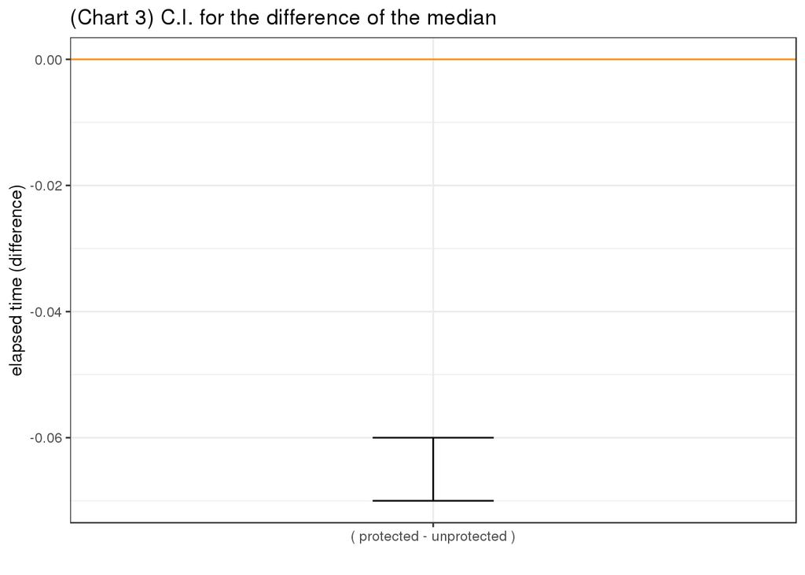

```r
X2.5 = c(result_med_diff$basic[4])
X97.5 = c(result_med_diff$basic[5])
elapsed.diff = data.frame(X2.5,X97.5)

elapsed.diff %>%
  ggplot(aes(x = "( protected - unprotected )",
             ymin = X2.5, ymax = X97.5)) +
  geom_errorbar(width = .2) +
  geom_hline(yintercept = 0, colour = "darkorange") +
  labs(x="", y="elapsed time (difference)") +
    ggtitle("(Chart 3) C.I. for the difference of the median")
```

##### Regarding the difference between `protected` and `unprotected` versions in median elapsed time, we can conclude that:

> The protected version is faster than the unprotected one.

### Explanation (why the difference?)

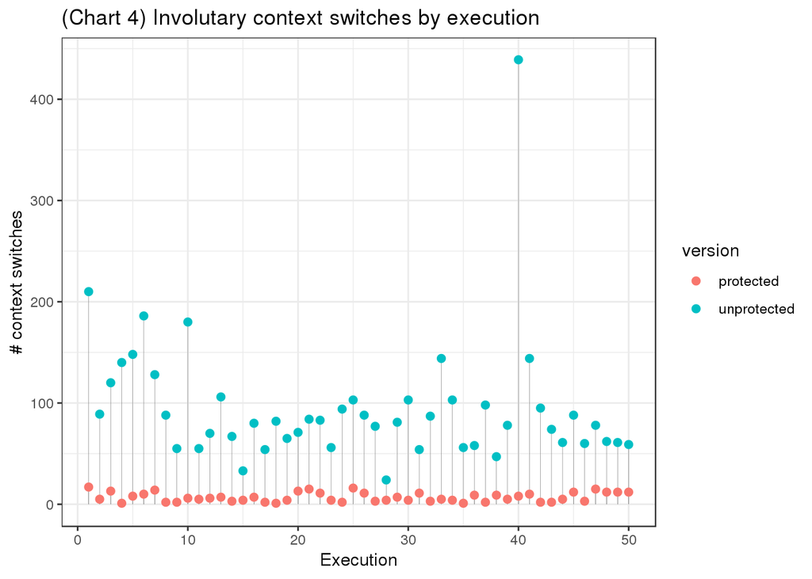

```r
perf_data %>%
  ggplot(aes(execution,inv_cxt_sw,color=version)) +
    geom_segment(aes(x = execution, y = 0,
                     xend = execution, yend = inv_cxt_sw),
                 color = "grey50", size=0.12) +
  geom_point(size=2) +
  labs(x="Execution", y="# context switches",
       title="(Chart 4) Involutary context switches by execution")
```

- There seems to be a substantial difference in the number of involuntary context switches each version is subjected to. The `unprotected` version seems to have experienced a much larger number of **involutary context switches**, which would account for the difference in elapsed time.

#### Statistical Inference

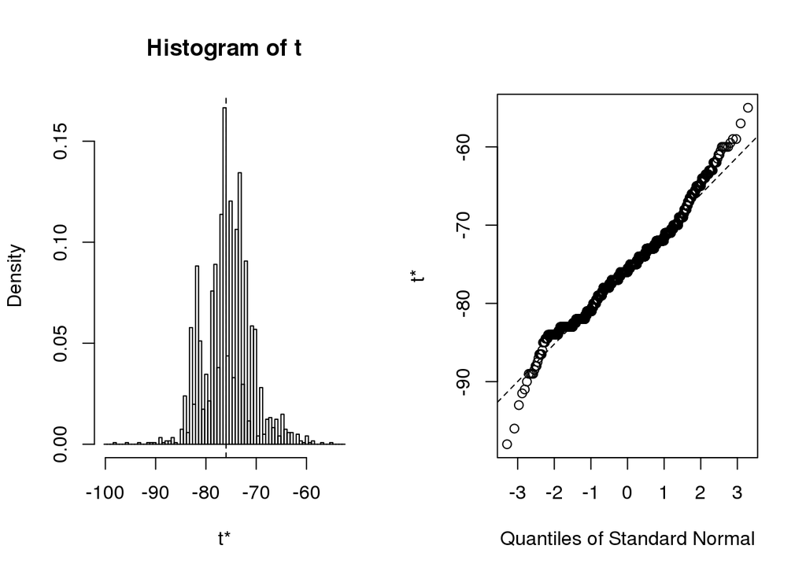

```r
my_theta <- function(x, i) {
    x %>%
        slice(i) -> d

    d %>%
      group_by(version) %>%
      summarise(med = median(inv_cxt_sw, na.rm = TRUE)) -> y

    med_diff = y[y$version == "protected",]$med - y[y$version == "unprotected",]$med

    return(med_diff)
}

med_inv_sw.boot <- boot(data = perf_data,
                 statistic = my_theta,
                 R = 2000)

plot(med_inv_sw.boot)
```

- We have a somewhat weird-tailed distributions, for this reason let’s use the `basic CI` (also called pivotal or empirical CI) to extract our results.

```r
result_med_inv_sw <- boot.ci(boot.out = med_inv_sw.boot,
        conf = 0.95,
        type = "basic")

result_med_inv_sw
```

```
## BOOTSTRAP CONFIDENCE INTERVAL CALCULATIONS
## Based on 2000 bootstrap replicates
##
## CALL :
## boot.ci(boot.out = med_inv_sw.boot, conf = 0.95, type = "basic")
##
## Intervals :
## Level      Basic
## 95%   (-87, -68 )
## Calculations and Intervals on Original Scale
```

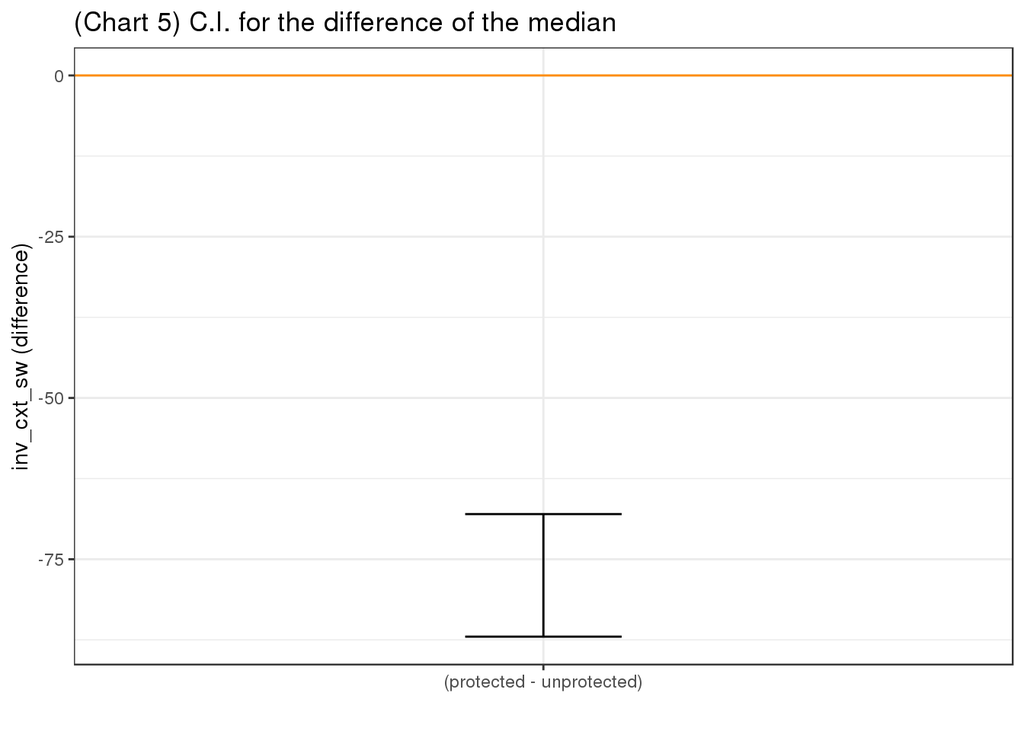

```r
X2.5 = c(result_med_inv_sw$basic[4])
X97.5 = c(result_med_inv_sw$basic[5])
inv_sw.diff = data.frame(X2.5,X97.5)

inv_sw.diff %>%
  ggplot(aes(x = "(protected - unprotected)",
             ymin = X2.5, ymax = X97.5)) +
  geom_errorbar(width = .2) +
  geom_hline(yintercept = 0, colour = "darkorange") +
  labs(x="", y="inv_cxt_sw (difference)") +
    ggtitle("(Chart 5) C.I. for the difference of the median")
```

##### Regarding the difference between `protected` and `unprotected` versions in median number of involuntary context switches, we can conclude that:

- As the C.I. does not intersect 0, we can say that it’s statistically significant
  - The `protected` version experienced less involuntary context switches than the `unprotected` one.
- By the scale of the C.I. we can say that it’s also relevant.

> So, we can point the difference in the number of involuntary context switches as evidence for the disparity in elapsed time between program versions.

# Question 2

- Code can be found at `code/list1/java-code/ex2/`

# Question 3

## C version

### Returns first result

- Code can be found at `code/list1/c-code/ex3/returns_first_ex3.c`

```c
#include <stdio.h>
#include <unistd.h>
#include <stdlib.h>
#include <stdint.h>
#include <pthread.h>

int f_sleep_time = -1;
pthread_mutex_t my_mutex = PTHREAD_MUTEX_INITIALIZER; /* mutex */
pthread_cond_t myConVar = PTHREAD_COND_INITIALIZER;   /* conditional variable */

void* request(void* args);
int gateway(int num_replicas);
int main(int argc, char *argv[]);

void* request(void* args)
{
  int sleep_time;
  int my_id = (intptr_t) args;

  sleep_time = 1 + rand() % 30;
  printf("Sleep time of thread %d: %ds\n", my_id, sleep_time);
  sleep (sleep_time);

  pthread_mutex_lock(&my_mutex);   /* Lock mutex*/
  f_sleep_time = sleep_time;
  pthread_cond_signal(&myConVar);
  pthread_mutex_unlock(&my_mutex); /* Unlock mutex */

  pthread_exit((void*) (intptr_t) sleep_time);
}


int gateway(int num_replicas)
{
  int i, result;

  pthread_t pthreads[num_replicas];

  for(i = 0; i < num_replicas; i++) {
    pthread_create(&pthreads[i], NULL, &request, (void*) (intptr_t) i);

  }

  pthread_mutex_lock(&my_mutex);            /* Lock mutex */

  while(f_sleep_time == -1) {                 /*  wait can end without any thread signaling */
    pthread_cond_wait(&myConVar, &my_mutex);  /* hence the while loop */
  }
  result = f_sleep_time;

  pthread_mutex_unlock(&my_mutex);          /*Unlock mutex*/

  return result;
}


int main(int argc, char *argv[])
{
  int seed, result, nthreads;

  /* Init random number generator*/
  seed = time(NULL);
  srand(seed);

  /* If receives one cmd line argument the argument is used as
   * number of threads, Else number of threads is 2 */
  if(argc == 2) {
    nthreads = strtol(argv[1], NULL, 10);
  } else {
    nthreads = 2;
  }

  printf("Number of threads: %d\n",nthreads);
  result = gateway(nthreads);
  printf("Result: %ds\n",result);

  return 0;
}
```

### Returns combined result

- Code can be found at `code/list1/c-code/ex3/returns_combined_ex3.c`

```c
#include <stdio.h>
#include <unistd.h>
#include <stdlib.h>
#include <stdint.h>
#include <pthread.h>

void* request(void* args);
int gateway(int num_replicas);
int main(int argc, char *argv[]);

void* request(void* args)
{
  int sleep_time;
  int my_id = (intptr_t) args;

  sleep_time = 1 + rand() % 30;
  printf("Sleep time of thread %d: %ds\n", my_id, sleep_time);
  sleep (sleep_time);

  pthread_exit((void*) (intptr_t) sleep_time);
}


int gateway(int num_replicas)
{
  int i, sleep;
  void *returnValue;
  int total_sleep = 0;

  pthread_t pthreads[num_replicas];

  for(i = 0; i < num_replicas; i++) {
    pthread_create(&pthreads[i], NULL, &request, (void*) (intptr_t) i);

  }

  for(i = 0; i < num_replicas; i++) {
    pthread_join(pthreads[i], &returnValue);
    sleep = (int) (intptr_t) returnValue;
    total_sleep += sleep;
  }
  return total_sleep;
}


int main(int argc, char *argv[])
{
  int seed, result, nthreads;

  /* Init random number generator*/
  seed = time(NULL);
  srand(seed);

  /* If receives one cmd line argument the argument is used as
   * number of threads, Else number of threads is 2 */
  if(argc == 2) {
    nthreads = strtol(argv[1], NULL, 10);
  } else {
    nthreads = 2;
  }

  printf("Number of Threads: %d\n", nthreads);
  result = gateway(nthreads);
  printf("Result: %ds\n", result);

  return 0;
}
```

## Java version

### Returns first result

- Code can be found at :
- `code/list1/java-code/ex3/first_return/Main.java`
- `code/list1/java-code/ex3/first_return/Requester.java`

#### Requester

```r
package ex_03.first_return;

import java.util.Random;

public class Requester implements Runnable {

    private int id;
    private static volatile int time = 0;

    public  Requester(int id) {
        this.id = id;
    }

    @Override
    public void run() {
        Random random = new Random();
        int sleepTime = 1 + random.nextInt(29);

        try {
            System.out.printf("Sleep time of thread %d: %ds\n", id, sleepTime);
            Thread.sleep(sleepTime * 1000);
            this.updateTime(sleepTime);
        } catch (InterruptedException e) {
            e.printStackTrace();
        }
    }

    public void updateTime(int time) {
        Requester.time = time;
    }

    public static int getTime() {
        return time;
    }
}
```

#### Main

```r
package ex_03.first_return;

public class Main {

    public static int gateway() {
        int num_replicas = 5;

        System.out.println(String.format("Number of threads: %d", num_replicas));

        for (int i = 0; i < num_replicas; i++) {
            Thread t = new Thread(new Requester(i));
            t.start();
        }

        while (true) {
            if(Requester.getTime() > 0) {
                return Requester.getTime();
            }
        }
    }

    public static void main(String[] args) {
        int result = gateway();
        System.out.println(String.format("Result: %d", result));
    }
}
```

### Returns combined result

- Code can be found at :
- `code/list1/java-code/ex3/combined_return/CombinedRequester.java`
- `code/list1/java-code/ex3/combined_return/CombinedMain.java`

#### Requester

```r
package ex_03.combined_return;

import ex_03.first_return.Requester;

public class CombinedRequester extends Requester {

    public CombinedRequester(int id) {
        super(id);
    }

    public void updateTime(int time) {
        int currentTime = CombinedRequester.getTime();
        super.updateTime(currentTime + time);
    }
}
```

#### Main

```r
package ex_03.combined_return;

public class CombinedMain {

    private static int gateway() {
        int num_replicas = 5;

        System.out.println(String.format("Number of threads: %d", num_replicas));

        Thread threads[] = new Thread[num_replicas];
        for (int i = 0; i < num_replicas; i++) {
            Thread t = new Thread(new CombinedRequester(i));
            threads[i] = t;
            t.start();
        }

        for(Thread t : threads) {
            try {
                t.join();
            } catch (InterruptedException e) {
                e.printStackTrace();
            }
        }
        return CombinedRequester.getTime();
    }

    public static void main(String[] args) {
        int result = gateway();
        System.out.println(String.format("Result: %d", result));
    }
}
```

# Question 4

## C version

### Returns first result

- Code can be found at `code/list1/c-code/ex4/returns_first_ex4.c`

```c
#include <stdio.h>
#include <unistd.h>
#include <stdlib.h>
#include <stdint.h>
#include <pthread.h>

int f_sleep_time = 0;
pthread_mutex_t my_mutex = PTHREAD_MUTEX_INITIALIZER; /* mutex */
pthread_cond_t myConVar = PTHREAD_COND_INITIALIZER;   /* conditional variable */

void* request(void* args);
void* time_out(void* args);
int gateway(int num_replicas);
int main(int argc, char *argv[]);

void* request(void* args)
{
  int sleep_time;
  int my_id = (intptr_t) args;

  sleep_time = 1 + rand() % 30;
  printf("Sleep time of thread %d: %ds\n", my_id, sleep_time);
  sleep (sleep_time);

  pthread_mutex_lock(&my_mutex);   /* Lock mutex*/
  f_sleep_time = sleep_time;
  pthread_cond_signal(&myConVar);
  pthread_mutex_unlock(&my_mutex); /* Unlock mutex */

  pthread_exit((void*) (intptr_t) sleep_time);
}


void* time_out(void* args)
{
  int max_time = 8;
  sleep (max_time);

  pthread_mutex_lock(&my_mutex);   /* Lock mutex*/
  f_sleep_time = -1;               /* Set invalid value*/
  pthread_cond_signal(&myConVar);
  pthread_mutex_unlock(&my_mutex); /* Unlock mutex */

  pthread_exit((void*) (intptr_t) max_time);
}


int gateway(int num_replicas)
{
  int i, result;
  pthread_t timeout;
  pthread_t pthreads[num_replicas];

  /* Start time out thread */
  pthread_create(&timeout, NULL, &time_out, NULL);

  for(i = 0; i < num_replicas; i++) {
    pthread_create(&pthreads[i], NULL, &request, (void*) (intptr_t) i);

  }

  pthread_mutex_lock(&my_mutex);            /* Lock mutex */

  while(f_sleep_time == 0) {                 /*  wait can end without any thread signaling */
    pthread_cond_wait(&myConVar, &my_mutex);  /* hence the while loop */
  }
  result = f_sleep_time;

  pthread_mutex_unlock(&my_mutex);          /*Unlock mutex*/

  return result;
}


int main(int argc, char *argv[])
{
  int seed, result, nthreads;

  /* Init random number generator*/
  seed = time(NULL);
  srand(seed);

  /* If receives one cmd line argument the argument is used as
   * number of threads, Else number of threads is 2 */
  if(argc == 2) {
    nthreads = strtol(argv[1], NULL, 10);
  } else {
    nthreads = 2;
  }

  printf("Number of threads: %d\n",nthreads);
  result = gateway(nthreads);
  printf("Result: %d\n",result);

  return 0;
}
```

### Returns combined result

- Code can be found at `code/list1/c-code/ex4/returns_combined_ex4.c`

```c
#include <errno.h>
#include <stdio.h>
#include <unistd.h>
#include <stdlib.h>
#include <stdint.h>
#include <pthread.h>
#include <sys/time.h>

int f_sleep_time = 0;
int n_released = 0;
pthread_mutex_t my_mutex = PTHREAD_MUTEX_INITIALIZER;
pthread_cond_t myConVar = PTHREAD_COND_INITIALIZER;

struct timespec
{
  time_t   tv_sec;        /* seconds */
  long     tv_nsec;       /* nanoseconds */
};

void* request(void* args);
void* timeout(void* args);
int gateway(int num_replicas);
int main(int argc, char *argv[]);


void* request(void* args)
{
  int sleep_time;
  int my_id = (intptr_t) args;

  sleep_time = 1 + rand() % 30;
  printf("Sleep time of thread %d: %ds\n", my_id, sleep_time);
  sleep (sleep_time);

  pthread_mutex_lock(&my_mutex);    /* Lock mutex */

  f_sleep_time = sleep_time;
  pthread_cond_signal(&myConVar);

  pthread_mutex_unlock(&my_mutex);  /* Unlock mutex */

  pthread_exit((void*) (intptr_t) sleep_time);
}


int gateway(int num_replicas)
{
  int i, n, sleep;
  struct timeval tv;
  struct timespec ts;
  int total_sleep = 0;
  int timeInMs = 16000;

  pthread_t pthreads[num_replicas];

  /* Start time struct */
  gettimeofday(&tv, NULL);
  ts.tv_sec = time(NULL) + timeInMs / 1000;
  ts.tv_nsec = tv.tv_usec * 1000 + 1000 * 1000 * (timeInMs % 1000);
  ts.tv_sec += ts.tv_nsec / (1000 * 1000 * 1000);
  ts.tv_nsec %= (1000 * 1000 * 1000);

  for(i = 0; i < num_replicas; i++) {
    pthread_create(&pthreads[i], NULL, &request, (void*) (intptr_t) i);
  }

  pthread_mutex_lock(&my_mutex);

  while(n_released < num_replicas) {           /* Escape if all threads are finished */
    n = pthread_cond_timedwait(&myConVar, &my_mutex, (void*) &ts);
    if(n == ETIMEDOUT) {
      total_sleep = -1;
      pthread_mutex_unlock(&my_mutex);
      break;
    }
    else if(n == 0){
      total_sleep += f_sleep_time;
      n_released += 1;
    }
  }

  pthread_mutex_unlock(&my_mutex);

  return total_sleep;
}


int main(int argc, char *argv[])
{
  int seed, result, nthreads;

  /* Init random number generator*/
  seed = time(NULL);
  srand(seed);

  if(argc == 2) {
    nthreads = strtol(argv[1], NULL, 10);
  } else {
    nthreads = 2;
  }

  printf("Number of Threads: %d\n", nthreads);
  result = gateway(nthreads);
  printf("Result: %ds\n", result);

  return 0;
}
```

## Java version

### Returns first result

- Code can be found at `code/list1/java-code/ex4/ReturnFirst.java`

```r
public class ReturnFirst extends Thread {
    public static final int TIMEOUT = 8000;
    private int id;

    public ReturnFirst(int id) throws InterruptedException {
        this.id = id;
        start();
    }

    public void run() {
        try {
            ReturnFirst.request();
        } catch (InterruptedException e) {
            e.printStackTrace();
        }
    }

    static int request() throws InterruptedException {
        int time = (int) (1 + Math.random() * 30);
        ReturnFirst.sleep(time * 1000);
        return time;
    }

    static int gateway(int nthreads) throws InterruptedException {
        int i;
        ReturnFirst[] threads = new ReturnFirst[nthreads];
        for (i = 0; i < nthreads; i++) {
            threads[i] = new ReturnFirst(i);
        }
        i = 1;
        long start = System.currentTimeMillis();
        while (threads[i-1].isAlive()) {
            i += 1;
            if (System.currentTimeMillis() - start >= TIMEOUT) {
                return -1;
            }
            if (i-1 == nthreads) {
                i = 1;
            }
        }
        return i;
    }

    public static void main(String[] args) throws InterruptedException {
        int num = Integer.parseInt(args[0]);
        System.out.println("Number of threads: " + num);
        int id = gateway(num);
        if (id == -1) {
            System.out.println("No threads are out in less than 8 seconds");
            return;
        }
        System.out.println("Result: " + id);
    }
}
```

### Returns combined result

- Code can be found at `code/list1/java-code/ex4/ReturnFirstCombined.java`

```r
public class ReturnFirstCombined extends Thread {
    private static final int TIMEOUT = 16000;
    private int id;
    private int time;

    public ReturnFirstCombined(int id) throws InterruptedException {
        this.id = id;
        start();
    }

    public int getTime() {
        return time;
    }

    public void run() {
        try {
            this.time = ReturnFirstCombined.request();
        } catch (InterruptedException e) {
            e.printStackTrace();
        }
    }

    static int request() throws InterruptedException {
        int time = (int) (1 + Math.random() * 30);
        ReturnFirst.sleep(time * 1000);
        return time;
    }

    static int gateway(int nthreads) throws InterruptedException {
        ReturnFirstCombined[] threads = new ReturnFirstCombined[nthreads];
        int i;
        int total = 0;
        for (i = 0; i < nthreads; i++) {
            threads[i] = new ReturnFirstCombined(i);
        }
        i = 0;
        long start = System.currentTimeMillis();
        do {
            if (!threads[i].isAlive()) {
                total += threads[i].getTime();
                i++;
            }
            if (System.currentTimeMillis() - start >= TIMEOUT) {
                return -1;
            }
        } while (i < nthreads);
        return total;
    }

    public static void main(String[] args) throws InterruptedException {
        int num = Integer.parseInt(args[0]);
        System.out.println("Number of threads: " + num);
        int id = gateway(num);
        if (id == -1) {
            System.out.println("No threads are out in less than 16 seconds");
            return;
        }
        System.out.println("Result: " + id);
    }
}
```

# Question 5

## Experiment Design

The data set shows the results of the experiment which consists in the insertion of elements in a collection with different numbers of threads:

Factors:

- `Collection`: Which collection is being measured
  - ConcurrentHashMap, SynchronizedMap, CopyOnWriteArrayList, SynchronizedRandomAccessList
- `Write Level`: Ratio of write/read operations
  - Level 1: 75% read 25% write
  - Level 2 = 50% read 50% write
  - Level 3 = 25% read 75% write
  - Level 4 = 100% write
- `Number of elements`: Number of elements added to the collection
  - 50, 100, 150, 200, 250, 300, 350, 400, 450, 500

Metrics:

- `Total Time`: Time taken to perform a batch of operations

## Implementation

- Code used to generate dataset can be found at `code/list1/java-code/ex5/Main.java`

```c
// package ex_05;

import java.util.ArrayList;
import java.util.Collections;
import java.util.HashMap;
import java.util.List;
import java.util.Map;
import java.util.concurrent.ConcurrentHashMap;
import java.util.concurrent.CopyOnWriteArrayList;
import java.util.concurrent.ExecutorService;
import java.util.concurrent.Executors;
import java.util.concurrent.TimeUnit;
import java.util.stream.Collectors;
import java.util.stream.IntStream;

/**
* Main
*/
public class Main {
    public final static int MAX_THREAD_POOL_SIZE = 10;
    public final static int ENTRIES_SIZE = 50;

    public static Map<String, Integer> concurrentHashMapObject = null;
    public static Map<String, Integer> synchronizedMapObject = null;
    public static List<Integer> copyOnWriteListObject = null;
    public static List<Integer> synchronizedListObject = null;

    public static void main(String[] args) throws InterruptedException {
        List<Integer> multiplierRange = IntStream.rangeClosed(1,10)
            .boxed().collect(Collectors.toList());
        List<Integer> writeLevels = IntStream.rangeClosed(1,4)
            .boxed().collect(Collectors.toList());
        List<Integer> rounds = IntStream.rangeClosed(1,15)
            .boxed().collect(Collectors.toList());
        copyOnWriteListObject = new CopyOnWriteArrayList<>();
        synchronizedListObject = Collections.synchronizedList(new ArrayList<Integer>());
        concurrentHashMapObject = new ConcurrentHashMap<String, Integer>();
        synchronizedMapObject = Collections.synchronizedMap(new HashMap<String, Integer>());

        rounds.forEach(r -> {
            writeLevels.forEach(wl -> {
                multiplierRange.forEach(multiplier -> {
                    try {
                        testMap(concurrentHashMapObject, multiplier, wl);
                        testMap(synchronizedMapObject, multiplier, wl);
                        testList(synchronizedListObject, multiplier, wl);
                        testList(copyOnWriteListObject, multiplier, wl);
                    } catch (Exception e) {
                        System.out.println(e.getMessage());
                    }
                });
            });
        });
    }

    public static void testList(final List<Integer> testCollection, int entriesMultiplier, int writeLevel) throws InterruptedException {
        for (int poolSize = 1; poolSize <= MAX_THREAD_POOL_SIZE; poolSize+=3) {

            ExecutorService executorServer = Executors.newFixedThreadPool(poolSize);
            int size = ENTRIES_SIZE * entriesMultiplier;
            long initialTime = System.nanoTime();

            for (int j = 0; j < poolSize; j++) {
                executorServer.execute(() -> {
                    for (int i = 0; i < size; i++) {

                        Integer random = (int) Math.ceil(Math.random() * 550000);
                        if (writeLevel == 4) {
                            testCollection.add(i, random);
                            testCollection.add(i, random);
                            testCollection.add(i, random);
                            testCollection.add(i, random);
                        }

                        if (writeLevel == 3) {
                            testCollection.add(i, random);
                            testCollection.add(i, random);
                            testCollection.add(i, random);
                            testCollection.get(i);
                        }

                        if (writeLevel == 2) {
                            testCollection.add(i, random);
                            testCollection.add(i, random);
                            testCollection.get(i);
                            testCollection.get(i);
                        }

                        if (writeLevel == 1) {
                            testCollection.add(i, random);
                            testCollection.get(i);
                            testCollection.get(i);
                            testCollection.get(i);
                        }
                    }
                });
            }

            executorServer.shutdown();
            executorServer.awaitTermination(Long.MAX_VALUE, TimeUnit.MINUTES);

            long finalTime = System.nanoTime();
            long totalTime = finalTime - initialTime;
            System.out.printf("%s,%d,%d,%d,%d" + System.lineSeparator(),
                testCollection.getClass().getSimpleName(),
                size, totalTime, poolSize, writeLevel
            );
        }
    }

    public static void testMap(final Map<String, Integer> testCollection, int entriesMultiplier, int writeLevel) throws InterruptedException {
        for (int poolSize = 1; poolSize <= MAX_THREAD_POOL_SIZE; poolSize+=3) {

            ExecutorService executorServer = Executors.newFixedThreadPool(poolSize);

            int size = ENTRIES_SIZE * entriesMultiplier;
            long initialTime = System.nanoTime();

            for (int j = 0; j < poolSize; j++) {
                executorServer.execute(() -> {
                    for (int i = 0; i < size; i++) {
                        Integer random = (int) Math.ceil(Math.random() * 550000);
                        if (writeLevel == 4) {
                            testCollection.put(String.valueOf(random), random);
                            testCollection.put(String.valueOf(random), random);
                            testCollection.put(String.valueOf(random), random);
                            testCollection.put(String.valueOf(random), random);
                        }

                        if (writeLevel == 3) {
                            testCollection.put(String.valueOf(random), random);
                            testCollection.put(String.valueOf(random), random);
                            testCollection.put(String.valueOf(random), random);
                            testCollection.get(String.valueOf(random));
                        }

                        if (writeLevel == 2) {
                            testCollection.put(String.valueOf(random), random);
                            testCollection.put(String.valueOf(random), random);
                            testCollection.get(String.valueOf(random));
                            testCollection.get(String.valueOf(random));
                        }

                        if (writeLevel == 1) {
                            testCollection.put(String.valueOf(random), random);
                            testCollection.get(String.valueOf(random));
                            testCollection.get(String.valueOf(random));
                            testCollection.get(String.valueOf(random));
                        }


                        testCollection.put(String.valueOf(random), random);
                        testCollection.get(String.valueOf(random));
                    }
                }
                );
            }

            executorServer.shutdown();
            executorServer.awaitTermination(Long.MAX_VALUE, TimeUnit.MINUTES);

            long finalTime = System.nanoTime();
            long totalTime = finalTime - initialTime;
            System.out.printf("%s,%d,%d,%d,%d" + System.lineSeparator(),
                testCollection.getClass().getSimpleName(),
                size, totalTime, poolSize, writeLevel
            );
        }
    }
}
```

## Result Analysis

```r
read_csv(here::here("output/list1/ex5/report.csv"),
         col_types = cols(
           class = col_character(),
           elements = col_integer(),
           total_time = col_double(),
           threads = col_integer(),
           write_level = col_integer()),
         progress = F) %>%
  mutate(total_time = total_time / 1000000) -> data

data %>%
  glimpse()
```

```
## Observations: 10,059
## Variables: 5
## $ class       <chr> "ConcurrentHashMap", "ConcurrentHashMap", "Concurr...
## $ elements    <int> 50, 50, 50, 50, 50, 50, 50, 50, 50, 50, 50, 50, 50...
## $ total_time  <dbl> 3.801518, 4.590778, 3.519674, 4.911861, 0.466765, ...
## $ threads     <int> 1, 4, 7, 10, 1, 4, 7, 10, 1, 4, 7, 10, 1, 4, 7, 10...
## $ write_level <int> 1, 1, 1, 1, 1, 1, 1, 1, 1, 1, 1, 1, 1, 1, 1, 1, 1,...
```

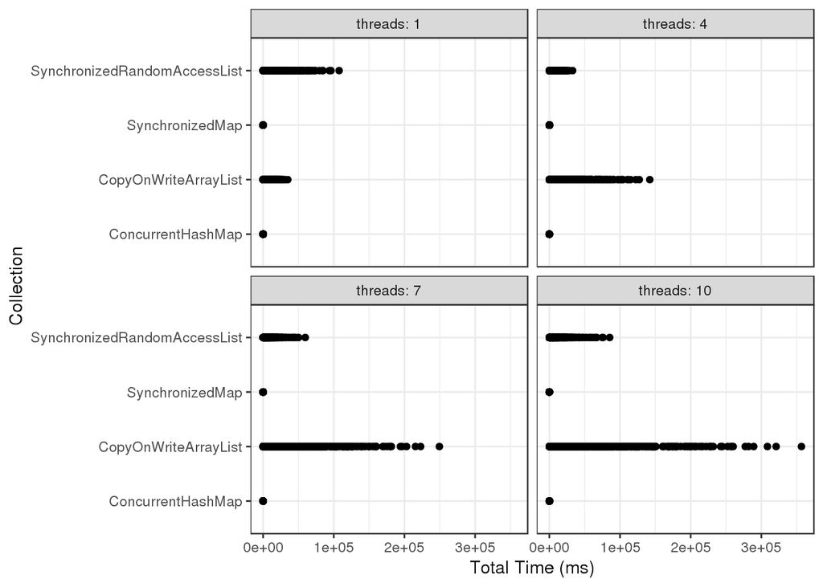

```r
data %>%
  ggplot(aes(total_time,class)) +
  geom_point() +
  facet_wrap(~threads, labeller = "label_both") +
  labs(x="Total Time (ms)",y="Collection")
```

- Map-based collections perform better than list-based collections in all cases.
- By exploring the data from a more general point of view, we can easily see the impact that the use of more threads simultaneously causes on the performance of certain collections, such as the `CopyOnWriteArrayList` case.
- In the `SynchronizedRandomAccessList` case, however:
  - There seems to happen an overall improvement when used with more than one thread,
  - Nonetheless, when this number of theads increases too much, it tends to suffer from the overhead caused by the synchronization work.

### Number of elements

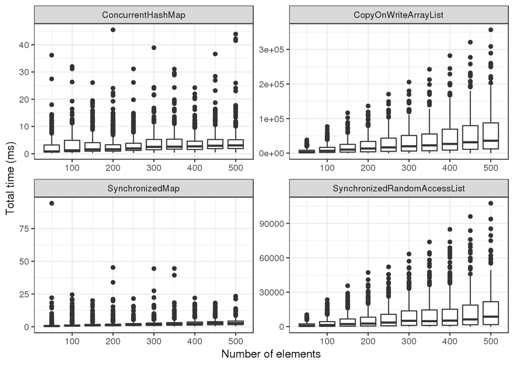

```r
data %>%
  ggplot(aes(y = total_time, x = elements, group=elements)) +
  geom_boxplot() +
  facet_wrap(~class, scales = "free") +
  labs(x="Number of elements", y="Total time (ms)")
```

- We can see that the total execution time for the **list-based** collections grows linearly with the number of elements inserted
- The total execution of map-based collections doesn’t seem rather random than related to the number of elements

> Because lists and maps have very different performance, we will keep them in different separate charts from now on.

### Write Level

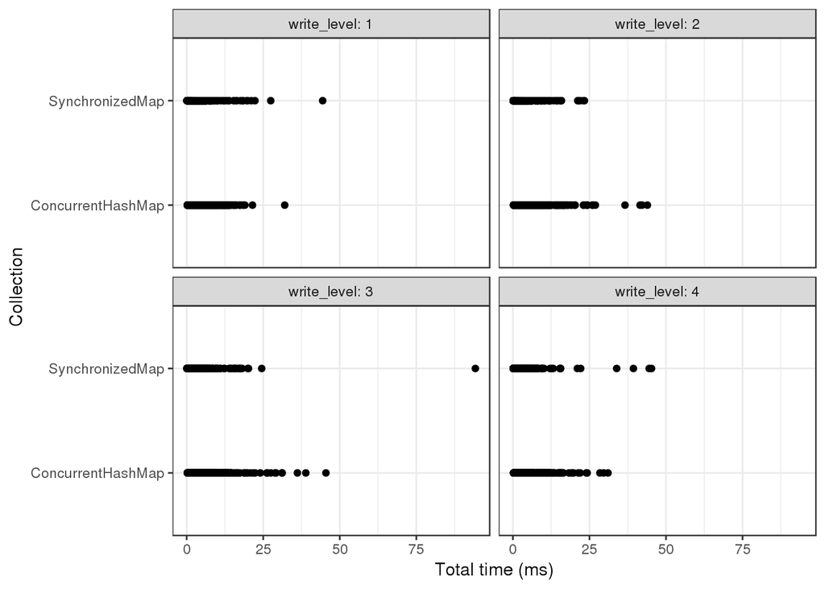

```r
data %>%
  filter(class != 'CopyOnWriteArrayList') %>%
  filter(class != 'SynchronizedRandomAccessList') %>%
  ggplot(aes(y = class, x = total_time)) +
  geom_point() +
  facet_wrap(~write_level, labeller="label_both") +
  labs(y="Collection", x="Total time (ms)")
```

- The proportion of writing and reading does not appear to consistently impact the performance of map-based collections as shown below with list-based collections

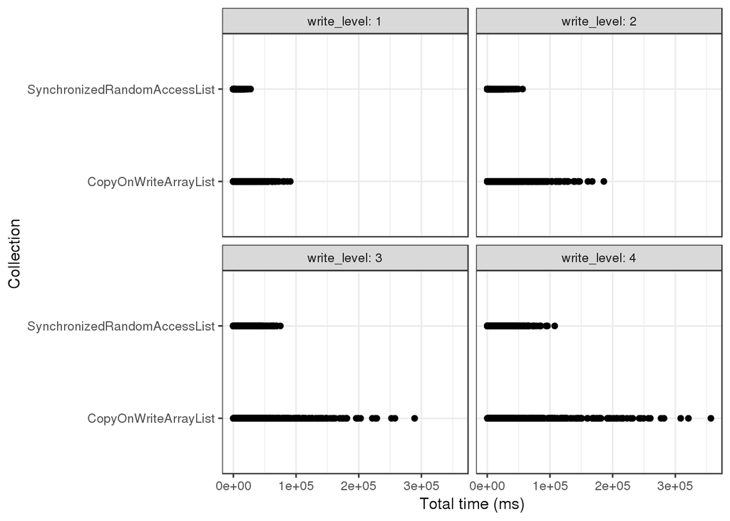

```r
data %>%
  filter(class != 'ConcurrentHashMap') %>%
  filter(class != 'SynchronizedMap') %>%
  ggplot(aes(y = class, x = total_time)) +
  geom_point() +
  facet_wrap(~write_level, labeller="label_both") +
  labs(y="Collection", x="Total time (ms)")
```

- In the lists the proportion of writing impacts greatly by the increase of elements themselves.

### Number of threads

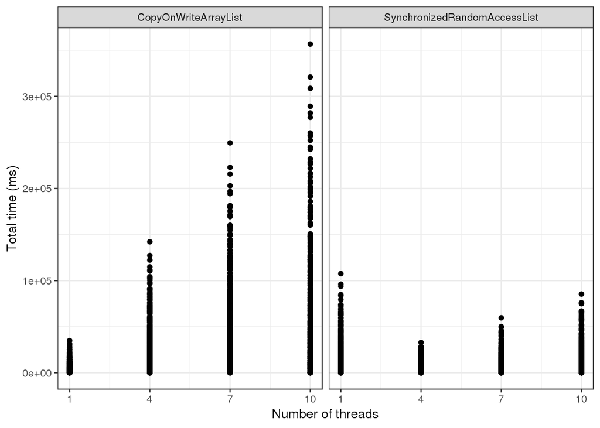

```r
data %>%
  filter(class != 'ConcurrentHashMap') %>%
  filter(class != 'SynchronizedMap') %>%
  ggplot(aes(x =threads, y = total_time)) +
  scale_x_continuous(breaks=seq(1, 10, 3)) +
  geom_point() +
  facet_wrap(~class) +
  labs(x="Number of threads", y="Total time (ms)")
```

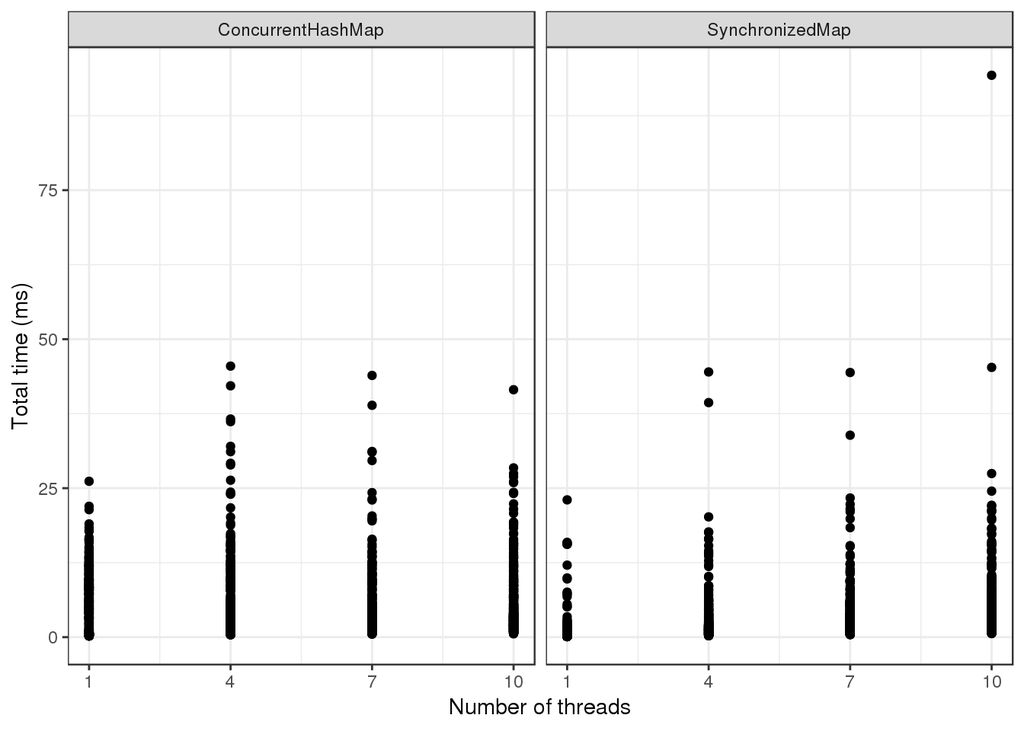

```r
data %>%
  filter(class != 'CopyOnWriteArrayList') %>%
  filter(class != 'SynchronizedRandomAccessList') %>%
  ggplot(aes(x =threads, y = total_time)) +
    scale_x_continuous(breaks=seq(1, 10, 3)) +
  geom_point() +
  facet_wrap(~class) +
  labs(x="Number of threads", y="Total time (ms)")
```

- In map-based collections the number of threads seems to have some impact but it does not follow a pattern, probably caused by the impact of thread synchronization.

## Summary

##### In general we can conclude that for **list-based** collections:

- The number of threads impact the performance of the collections, such as CopyOnWriteArrayList whose performance worsens as the number of threads increases.
- The SynchronizedRandomAccessList whose performance seems to improve when its number of threads increases from a single thread to a few ones. Later, as the number of threads increases greatly their performance degraded.

##### In general we can conclude that for **map-based** collections:

- The impact of the number of theads seems to be smaller and more random, probably caused by synchronization and moments where multiple threads are locked at the same time.